# Sales

Oscar

2/6/2021

#### Time Series Analysis

We will forecast our sales by using weekly data from the data set that we used in our python project. This will give us about 143 observations with which to forecast. First here is a plot of our weekly sales from 2010-02-05 to 2012-10-26.

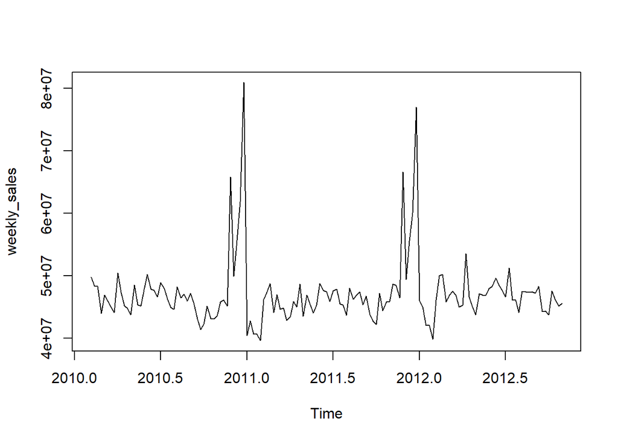

As you can see our sales seem to spike around the end of the year, most likely because of the holiday sales boom that retail stores typically get.  
Before we do any forecasting we need to decide on some baseline models to use as a benchmark. This will allow us to compare seemingly simpler forecasting models with more complicated models. We will use the mean, naive, and seasonal naive as our baseline models. Down below we plot them.

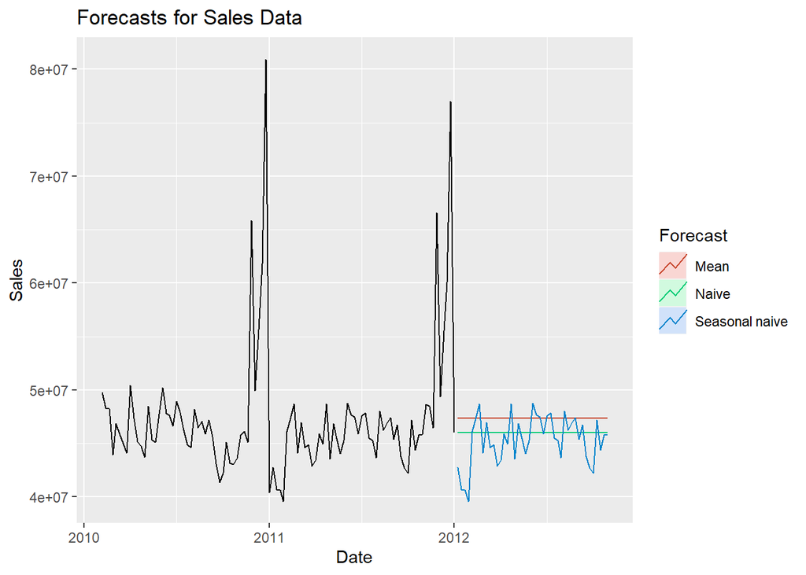

We first partition our data into train and test splits. The training data is what we use to train our model on. While the testing data is how we evaluate our models performance against data that it hasn’t been trained on. Up above the *mean* forecast is merely the historical average of the data. The *naive* forecast is simply the value of the last observation. While the *seasonal naive* forecast is equal to the last observed value from the same period in the previous year.

Since our data is highly seasonal we are most concerned with the seasonal naive method. Below we show the accuracy metrics for the seasonal naive method.

```
##                   ME    RMSE     MAE       MPE     MAPE     MASE       ACF1
## Training set  -91460 2009836 1387984 -0.160249 2.917466 1.000000 0.19892562
## Test set     1166821 1985905 1483137  2.437898 3.129202 1.068555 0.03856437
##              Theil's U
## Training set        NA
## Test set     0.7047942
```

As you can see our mean absolute error (MAE) is 1,387,984 for the training set and 1,483,137 for the test set. This means that on average with our testing data we are off by about 1,483,137 from the true value. There’s a couple of things to keep in mind when hearing this forecast. First, we only have about 2 years or 104 weeks of weekly data to forecast off of. Ideally we would want several years worth of data to give effective accurate forecasts. This is to ensure that we have enough data to capture and deal with periodic effects such as seasonality. Second, we are forecasting quite far out into the future (about 43 weeks). If we were forecasting not so far out say only a couple of weeks our forecasts and thus MAE would be more accurate.

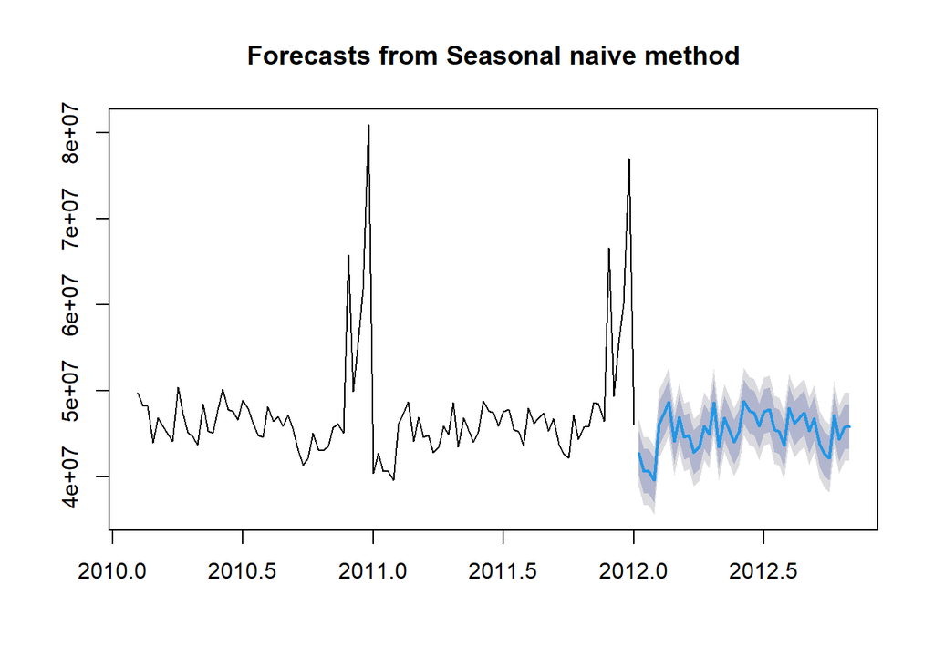

The forecast you see above shows the prediction intervals. The 95% prediction interval is shown in light gray while the 80% interval is shown in dark gray. Below I show our forecast numbers which include the date, point estimate, 80% and 95% prediction interval for all 43 weeks of our forecast.

```
##          Date Point Forecast    Lo 80    Hi 80    Lo 95    Hi 95
## 1  2012-01-07       42775788 40200079 45351497 38836581 46714995
## 2  2012-01-14       40673678 38097969 43249387 36734471 44612885
## 3  2012-01-21       40654648 38078939 43230357 36715441 44593855
## 4  2012-01-29       39599853 37024144 42175562 35660646 43539060
## 5  2012-02-05       46153111 43577402 48728820 42213904 50092318
## 6  2012-02-12       47336193 44760484 49911902 43396986 51275400
## 7  2012-02-19       48716164 46140455 51291873 44776957 52655371
## 8  2012-02-26       44125860 41550151 46701569 40186653 48065067
## 9  2012-03-04       46980604 44404895 49556313 43041397 50919811
## 10 2012-03-11       44627319 42051610 47203028 40688113 48566526
## 11 2012-03-18       44872326 42296617 47448035 40933119 48811533
## 12 2012-03-25       42876199 40300490 45451908 38936992 46815406
## 13 2012-04-01       43458991 40883282 46034700 39519784 47398198
## 14 2012-04-08       45887467 43311758 48463176 41948260 49826674
```

[output cut: 29 more lines]

### STL Decomposition and Exponential Smoothing

Time series decomposition simply means too break up time series date into different components. One such method is called “Seasonal and Trend decomposition using Loess” or STL for short. We can then use this decomposition to help us forecast values by combining it with another forecasting method. We will now forecast our sales data using STL decomposition along with exponential smoothing (ETS).

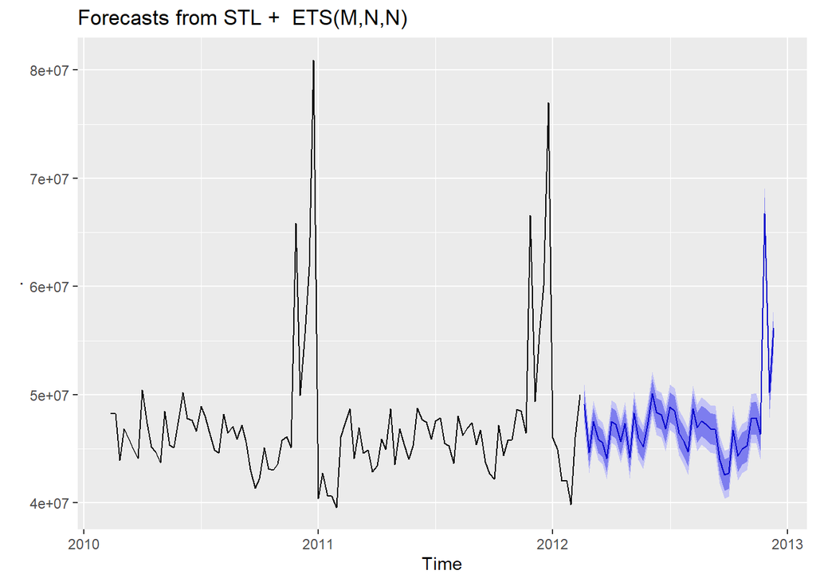

```
##                      ME      RMSE       MAE         MPE     MAPE      MASE
## Training set   6214.256  931633.6  653161.3 -0.02322703 1.369993 0.4878678
## Test set     459979.936 1606675.9 1185812.3  0.91312824 2.483784 0.8857225
##                    ACF1 Theil's U
## Training set  0.1389597        NA
## Test set     -0.2374639 0.6196751
```

As you can see we improved upon our previous seasonal naive model. Our mean absolute error using STL and ETS for the test set is 1,185,812.3. We beat our previous error for the seasonal naive model by about 297,324.7. The MASE error on the far right also confirms this. A MASE below one means that the current model is better than the average naive model.

It appears that our Exponential Smoothing model beat out our previous baseline model. We can now use this model for forecasting any future sales. Below we list our forecasting for the future 43 weeks using our new model.

```
##          Date Point Forecast    Lo 80    Hi 80    Lo 95    Hi 95
## 1  2012-02-19       49092492 47872280 50312705 47226338 50958647
## 2  2012-02-26       44651828 43423466 45880190 42773211 46530445
## 3  2012-03-04       47532516 46296059 48768973 45641518 49423514
## 4  2012-03-11       45879974 44635474 47124474 43976675 47783272
## 5  2012-03-18       45540412 44287921 46792903 43624892 47455932
## 6  2012-03-25       44112905 42852473 45373336 42185241 46040569
## 7  2012-04-01       47531408 46263086 48799731 45591676 49471140
## 8  2012-04-08       47237506 45961341 48513671 45285780 49189231
## 9  2012-04-15       45696073 44412114 46980032 43732427 47659718
## 10 2012-04-22       47339126 46047420 48630832 45363632 49314620
## 11 2012-04-29       44238330 42938923 45537738 42251058 46225602
## 12 2012-05-06       48296739 46989676 49603802 46297758 50295719
## 13 2012-05-13       46006856 44692182 47321530 43996235 48017477
## 14 2012-05-20       45196446 43874204 46518688 43174252 47218641
```

[output cut: 29 more lines]